# Modulo 1 Geostatistica - corso base

# Unire tabelle (join)

Vediamo un esempio pratico: andiamo ad unire i valori di oggi a quelli di alcuni giorni fa alle nostre stazioni. [Scarica qui il dato CSV](https://www.cirgeo.unipd.it/archivio/shared/R/ARPA2024_corsoBase/dati/ARPA_temperatura_20240528.csv).

```r
dt.past <- read.csv("dati/ARPA_temperatura_20240528.csv")
dt.past <- dt.past %>% select(statnm, statcd, dataora, media)
dt.joined <- dt.past %>%  left_join(dtf, by=c("statcd"="codice_stazione") )
```

# Esercizio 2

# Ristrutturazione: wide=>long

Questo tipo di modifica è molto comune per rappresentare i dati in modo differente. Vediamo un esempio pratico:

```r
## andiamo a creare classi di temperatura
classi <- cut(dtf$valore, breaks = c(-10,0,10,20,30))
## mappatura con tabella a doppia entrata
tb.wide <- table(dtf$provincia, classi)
## nota che è un oggetto "table", trasformiomo in data.frame
tb.wide <- as.data.frame.matrix(tb.wide)
rownames(tb.wide)
```

```
## [1] "BELLUNO" "PADOVA"  "ROVIGO"  "TREVISO" "UDINE"   "VENEZIA" "VERONA"
## [8] "VICENZA"
```

```r
## nota ancora che le provincie sono rownames - se converto
## a tibble non ci sono pià
rownames(as_tibble(tb.wide) )
```

```
## [1] "1" "2" "3" "4" "5" "6" "7" "8"
```

```r
## creo colonna e relacate la mette all'inizio (provate senza "relocate")
tb.wide <- tb.wide %>% mutate(Provincie = rownames(tb.wide))%>%  relocate(Provincie)
## tabella con numero di stazioni per classe espressa "wide"
tb.wide
```

```
##         Provincie (-10,0] (0,10] (10,20] (20,30]
## BELLUNO   BELLUNO       4     34      11       0
## PADOVA     PADOVA       0      0      10       0
## ROVIGO     ROVIGO       0      0       6       0
## TREVISO   TREVISO       0      1      15       0
## UDINE       UDINE       0      1       0       0
## VENEZIA   VENEZIA       0      0      15       0
## VERONA     VERONA       0      4       9       0
## VICENZA   VICENZA       0     13      23       0
```

```r
## trasformo
tb.long <- tb.wide  %>% pivot_longer(!Provincie,
    names_to = "Classe Temp. °C", values_to = "Numero"
    )
tb.long
```

```
## # A tibble: 32 × 3
##    Provincie `Classe Temp. °C` Numero
##    <chr>     <chr>              <int>
##  1 BELLUNO   (-10,0]                4
##  2 BELLUNO   (0,10]                34
##  3 BELLUNO   (10,20]               11
##  4 BELLUNO   (20,30]                0
##  5 PADOVA    (-10,0]                0
##  6 PADOVA    (0,10]                 0
##  7 PADOVA    (10,20]               10
##  8 PADOVA    (20,30]                0
##  9 ROVIGO    (-10,0]                0
## 10 ROVIGO    (0,10]                 0
## # ℹ 22 more rows
```

# Ristrutturazione: long=>wide

Operazione inversa per tornare alla tabella di origine

```r
tb.long2wide <- tb.long  %>% pivot_wider(
  names_from = "Classe Temp. °C", values_from = "Numero"
  )
tb.long2wide
```

```
## # A tibble: 8 × 5
##   Provincie `(-10,0]` `(0,10]` `(10,20]` `(20,30]`
##   <chr>         <int>    <int>     <int>     <int>
## 1 BELLUNO           4       34        11         0
## 2 PADOVA            0        0        10         0
## 3 ROVIGO            0        0         6         0
## 4 TREVISO           0        1        15         0
## 5 UDINE             0        1         0         0
## 6 VENEZIA           0        0        15         0
## 7 VERONA            0        4         9         0
## 8 VICENZA           0       13        23         0
```

# Grafici con GGplot

Le funzioni di base “`plot`” sono utili ma ci sono librerie che forniscono più funzionalità. Introduciamo “ggplot”. Notate che viene creato un grafico concatenando con l’operatore “`+`” gli oggetti del grafico. “`aes`” sta per *aestethics* e indica colori e valori degli assi, aggregazioni ecc…

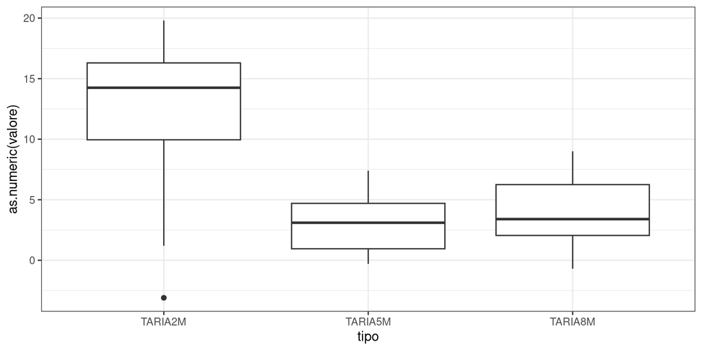

```r
library(ggplot2)
ggplot(dtf) + geom_boxplot(aes(x=tipo, y=as.numeric(valore) )) + theme_bw()
```

# Grafici con GGplot

NB. la parte “as.numeric” in quanto la colonna anche contiene numeri è di tipo “character”. Modifichiamola con “as.numeric”, ma vedrete due valori mancanti (NA=not available).

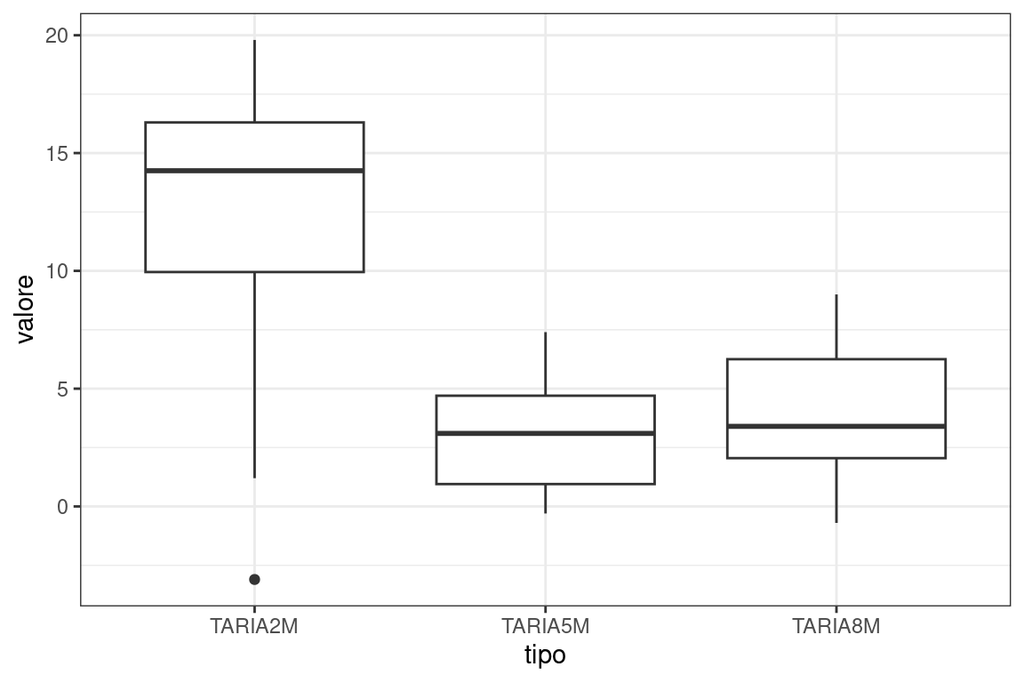

```r
dtf$valore <- as.numeric(dtf$valore)
ggplot(dtf) + geom_boxplot(aes(x=tipo, y=valore )) + theme_bw()
```

# Grafici e dati geo

Abbiamo colonne con coordinate: possiamo creare un grafico con uno sfondo territoriale e considerare delle colonne come coordinate? Per dati geo usiamo libreria *sf* e *terra*. Non indispensabili per geostatistica, ma fortemente consigliati.

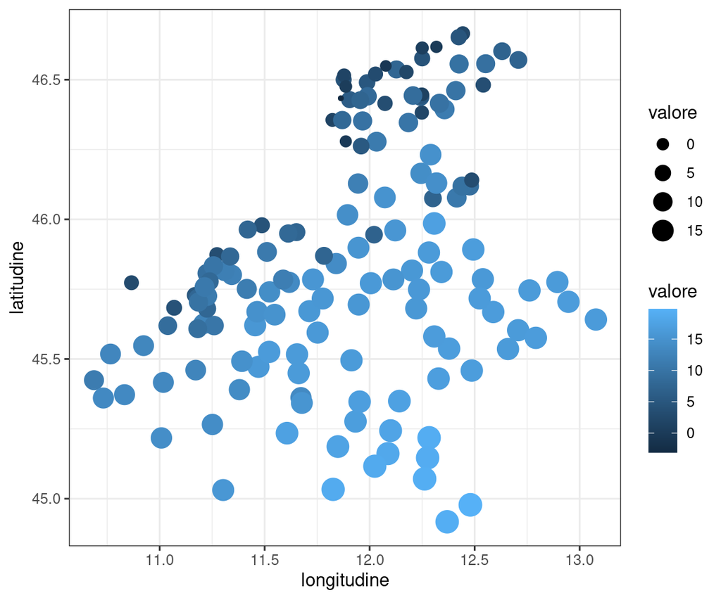

```r
library(ggspatial, quietly = T)
library(sf)  ## se non l'avete installata non vi preoccupate
theme_set(theme_bw())
ggplot(dtf) + geom_point(aes(x=longitudine, y=latitudine, color=valore, size=valore ))
```

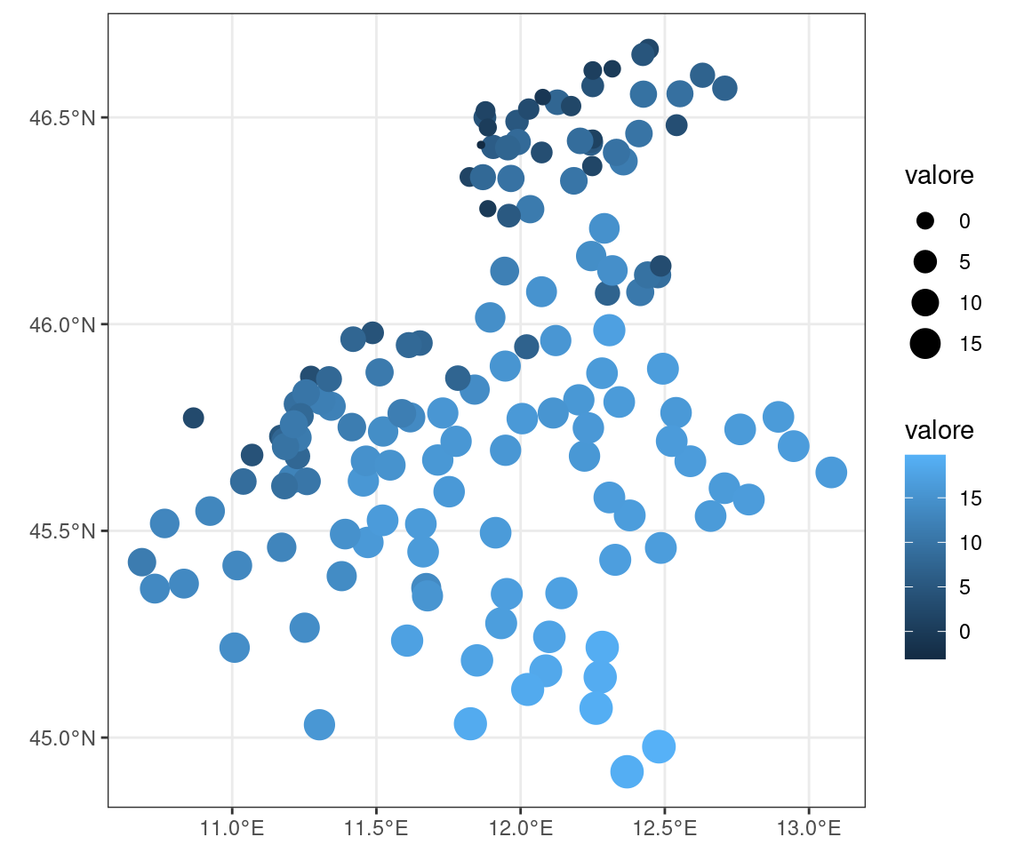

```r
dtf.geo <- sf::st_as_sf(dtf,coords = c("longitudine","latitudine"), crs=4326 )
ggplot(dtf.geo) + geom_sf(aes(color=valore, size=valore )) + coord_sf()
```

# Dati geospaziali

# Introduzione

A grandi linee i dati spaziali sono interpretati digitalmente mediante due modelli: il modello vettoriale ed il modello raster. In entrambi i casi va comunque compreso che ogni elemento è georiferito, ovvero ha una localizzazione in un sistema di riferimento, quindi delle coordinate.

# Dati vettoriali

I dati vettoriali hanno tre primitive geometriche di base: punti linee e poligoni. La base è sempre il punto con una coordinate, in 2d o 3d.

Ci sono decine di formati di file che rappresentano dati vettoriali. Ne abbiamo visto uno all’inizio, il file JSON! Per un riferimento vedete la [pagina QUI](https://gdal.org/drivers/vector/index.html)

# Raster

Il formato raster è molto semplice: sono nodi a passo costante, quindi una “griglia” georiferita mediante uno o più punti. Il passo della griglia è spesso identico nelle due direzioni (ma non necessariamente), e ne determina la risoluzione spaziale.

Ci sono decine di formati di file che rappresentano dati raster. Per un riferimento vedete la [pagina QUI](https://gdal.org/drivers/raster/index.html)

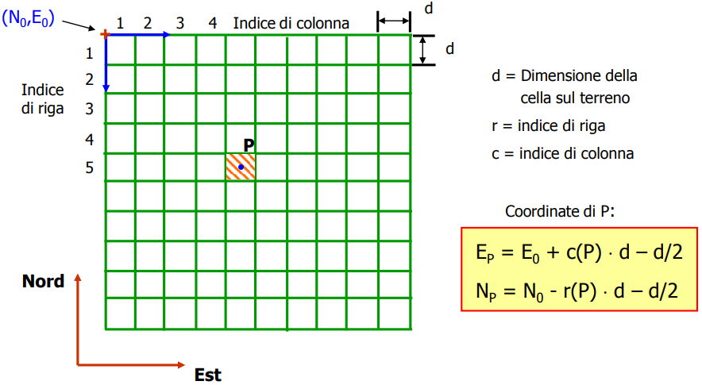